# Predicting House Prices With Linear Regression

taol4,cyshek2,wanliny2

August 1, 2019

# Group Members

- Tao Li (taol4)
- Chun Yue Shek (cyshek2)
- Wanlin Yang (wanliny2)

# Introduction

**Predicting House Prices With Linear Regression**

Ask a home buyer to describe their dream house, and they probably won’t begin with the height of the basement ceiling or the proximity to an east-west railroad. But this dataset in our project proves that much more influences price negotiations than the number of bedrooms or a white-picket fence.

We will use 79 explanatory variables describing (almost) every aspect of residential homes in Ames, Iowa, we will try all the techniques learned in this lession to predict the final price of each home.

## Dataset

### About the dataset

We will use the [Real Estate Data](https://www.kaggle.com/c/house-prices-advanced-regression-techniques/data) dataset for our final project.

- train.csv - the training set
- test.csv - the test set
- data_description.txt - full description of each column, originally prepared by Dean De Cock but lightly edited to match the column names used here

### Understand the dataset

This data is the real estate information with publicly available.Features include LotArea (Lot size in square feet), # of Bedroom, and # of Kitchen There are also categorical features, such as GarageType and MSSubClass(Building class), Utilities.

Here’s a brief version of what you’ll find in the data description file.

- SalePrice - the property’s sale price in dollars. This is the target variable that you’re trying to predict.
- MSSubClass: The building class
- MSZoning: The general zoning classification
- LotFrontage: Linear feet of street connected to property
- LotArea: Lot size in square feet
- Street: Type of road access
- Alley: Type of alley access
- LotShape: General shape of property
- LandContour: Flatness of the property
- Utilities: Type of utilities available
- LotConfig: Lot configuration
- LandSlope: Slope of property
- Neighborhood: Physical locations within Ames city limits
- Condition1: Proximity to main road or railroad
- Condition2: Proximity to main road or railroad (if a second is present)
- BldgType: Type of dwelling
- HouseStyle: Style of dwelling
- OverallQual: Overall material and finish quality
- OverallCond: Overall condition rating
- YearBuilt: Original construction date
- YearRemodAdd: Remodel date
- RoofStyle: Type of roof
- RoofMatl: Roof material
- Exterior1st: Exterior covering on house
- Exterior2nd: Exterior covering on house (if more than one material)
- MasVnrType: Masonry veneer type
- MasVnrArea: Masonry veneer area in square feet
- ExterQual: Exterior material quality
- ExterCond: Present condition of the material on the exterior
- Foundation: Type of foundation
- BsmtQual: Height of the basement
- BsmtCond: General condition of the basement
- BsmtExposure: Walkout or garden level basement walls
- BsmtFinType1: Quality of basement finished area
- BsmtFinSF1: Type 1 finished square feet
- BsmtFinType2: Quality of second finished area (if present)
- BsmtFinSF2: Type 2 finished square feet
- BsmtUnfSF: Unfinished square feet of basement area
- TotalBsmtSF: Total square feet of basement area
- Heating: Type of heating
- HeatingQC: Heating quality and condition
- CentralAir: Central air conditioning
- Electrical: Electrical system
- 1stFlrSF: First Floor square feet
- 2ndFlrSF: Second floor square feet
- LowQualFinSF: Low quality finished square feet (all floors)
- GrLivArea: Above grade (ground) living area square feet
- BsmtFullBath: Basement full bathrooms
- BsmtHalfBath: Basement half bathrooms
- FullBath: Full bathrooms above grade
- HalfBath: Half baths above grade
- Bedroom: Number of bedrooms above basement level
- Kitchen: Number of kitchens
- KitchenQual: Kitchen quality
- TotRmsAbvGrd: Total rooms above grade (does not include bathrooms)
- Functional: Home functionality rating
- Fireplaces: Number of fireplaces
- FireplaceQu: Fireplace quality
- GarageType: Garage location
- GarageYrBlt: Year garage was built
- GarageFinish: Interior finish of the garage
- GarageCars: Size of garage in car capacity
- GarageArea: Size of garage in square feet
- GarageQual: Garage quality
- GarageCond: Garage condition
- PavedDrive: Paved driveway
- WoodDeckSF: Wood deck area in square feet
- OpenPorchSF: Open porch area in square feet
- EnclosedPorch: Enclosed porch area in square feet
- 3SsnPorch: Three season porch area in square feet
- ScreenPorch: Screen porch area in square feet
- PoolArea: Pool area in square feet
- PoolQC: Pool quality
- Fence: Fence quality
- MiscFeature: Miscellaneous feature not covered in other categories
- MiscVal: $Value of miscellaneous feature
- MoSold: Month Sold
- YrSold: Year Sold
- SaleType: Type of sale
- SaleCondition: Condition of sale

## Motivation and Goal

### Motivation

This dataset gives us a chance to look into the data on what really influences the value of a house, so our team members are excited to take a look!

It will be applealing to analyze housing data and deliver a good model predicting price given the predictors of housing information. We may apply the model over the houses we have known around us, and analyse whether there can be some potential influence to the house price that cannot be reflected by data.

### Goals

We plan to

- Assemble the data and explore the coorelation
- Clean variables, filtering the outliers and perform feature transformation and selections.
- Build the best model levergaing the knowledge in this course..

To evaluate the model, we want to use Root-Mean-Squared-Error (RMSE) between the logarithm of the predicted value and the logarithm of the observed sales price. (Taking logs means that errors in predicting expensive houses and cheap houses will affect the result equally.) The definition of RMSE will stay the same

$$\text{RMSE}(\text{model, data}) = \sqrt{\frac{1}{n} \sum_{i = 1}^{n}(y_i - \hat{y}_i)^2}$$

where

- $y_i$ are the actual values of the response for the given data.
- $\hat{y}_i$ are the predicted values using the fitted model and the predictors from the data.

# Methods

## Load the data

Firstly we can load the data from `csv` file, while the `Id` row will not be included in this dataset.

```r
data = read.csv("train.csv")

#Remove Id from data
rownames(data) = data$Id
data = data[, -which(names(data) %in% c("Id"))]
```

We want to make some value cleaning and fix invalid data values in the data.

```r
# remove missing data, which is stored as "?"
data = subset(data, data$GarageType != "?")

#Fix some NAs
data$GarageYrBlt[is.na(data$GarageYrBlt)] = 1
data$MasVnrArea[is.na(data$MasVnrArea)] = 1
data$LotFrontage[is.na(data$LotFrontage)] = 1
```

## Feature Analysis

### Coorelation Analysis

In this project, we have a big challenge on the massive predictors. In order to select best correlated predictors and reduce the model complexity. We tried to compute the coorelation for each predictors to the response.

```r
#Try correlation only for numeric features
data_numeric = data[, unlist(lapply(data, is.numeric))]

numericFeatures = names(data_numeric)
numericFeatures = numericFeatures[!numericFeatures %in% c("SalePrice")]

n = length(numericFeatures)
correlations_na_na = rep(0.0, n)
correlations_log_na = rep(0.0, n)
correlations_na_log = rep(0.0, n)
correlations_log_log = rep(0.0, n)

for(i in 1:n){
  correlations_na_na[i] = cor(data[,numericFeatures[i]], data[,"SalePrice"])
  correlations_log_na[i] = cor(log(data[,numericFeatures[i]] +1), data[,"SalePrice"])
  correlations_na_log[i] = cor(data[,numericFeatures[i]], log(data[,"SalePrice"]))
  correlations_log_log[i] = cor(log(data[,numericFeatures[i]]+1), log(data[,"SalePrice"]))
}

colFeaturesName = rep("", n-1)
colFeaturesCorr = rep(0.0, n-1)

featureStat = data.frame(features = numericFeatures,
                   abs_correlations = round(abs(correlations_na_na),2),
                   correlations_na_na = round(correlations_na_na,2),
                   correlations_log_na = round(correlations_log_na,2),
                   correlations_na_log = round(correlations_na_log,2),
                   correlations_log_log = round(correlations_log_log,2)
                   )
featureStat = featureStat[order(-featureStat$abs_correlations),]
library("knitr")
kable(head(featureStat, 20))
```

|  | features | abs_correlations | correlations_na_na | correlations_log_na | correlations_na_log | correlations_log_log |
| --- | --- | --- | --- | --- | --- | --- |
| 4 | OverallQual | 0.79 | 0.79 | 0.75 | 0.81 | 0.80 |
| 16 | GrLivArea | 0.71 | 0.71 | 0.69 | 0.70 | 0.73 |
| 26 | GarageCars | 0.64 | 0.64 | 0.61 | 0.65 | 0.64 |
| 27 | GarageArea | 0.61 | 0.61 | 0.58 | 0.61 | 0.61 |
| 12 | TotalBsmtSF | 0.60 | 0.60 | 0.32 | 0.60 | 0.36 |
| 13 | X1stFlrSF | 0.59 | 0.59 | 0.58 | 0.59 | 0.59 |
| 19 | FullBath | 0.56 | 0.56 | 0.53 | 0.60 | 0.58 |
| 23 | TotRmsAbvGrd | 0.54 | 0.54 | 0.52 | 0.54 | 0.54 |
| 6 | YearBuilt | 0.51 | 0.51 | 0.51 | 0.57 | 0.57 |
| 7 | YearRemodAdd | 0.51 | 0.51 | 0.51 | 0.57 | 0.57 |
| 25 | GarageYrBlt | 0.49 | 0.49 | 0.48 | 0.54 | 0.54 |
| 8 | MasVnrArea | 0.46 | 0.46 | 0.39 | 0.42 | 0.40 |
| 24 | Fireplaces | 0.45 | 0.45 | 0.46 | 0.48 | 0.49 |
| 9 | BsmtFinSF1 | 0.38 | 0.38 | 0.17 | 0.36 | 0.18 |
| 29 | OpenPorchSF | 0.33 | 0.33 | 0.43 | 0.36 | 0.47 |
| 14 | X2ndFlrSF | 0.31 | 0.31 | 0.16 | 0.31 | 0.17 |
| 28 | WoodDeckSF | 0.31 | 0.31 | 0.31 | 0.32 | 0.33 |
| 20 | HalfBath | 0.27 | 0.27 | 0.28 | 0.30 | 0.31 |
| 3 | LotArea | 0.25 | 0.25 | 0.37 | 0.25 | 0.38 |
| 17 | BsmtFullBath | 0.23 | 0.23 | 0.23 | 0.24 | 0.24 |

Based on the predictor correlation analysis. Let’s plot the charts to understand how these top predictors correlated to the response. Here we picked **OverallQual**, **GrLivArea**, **GarageCars**, **TotalBsmtSF**, **X1stFlrSF**, **GarageArea**, **FullBath**, **YearBuilt**

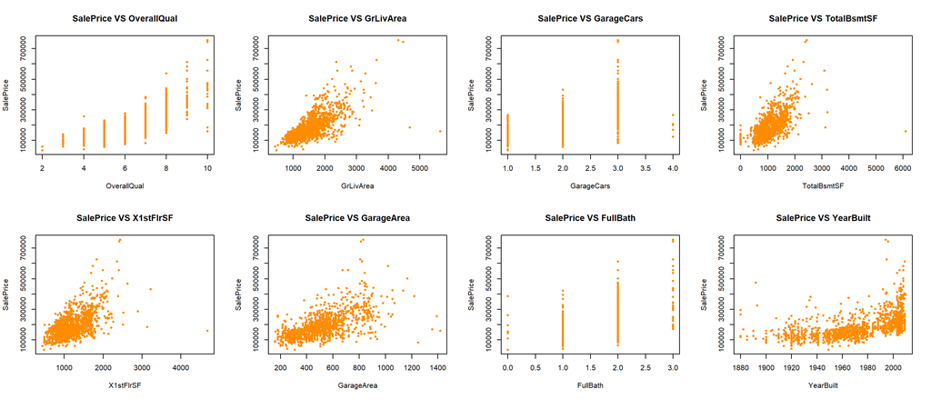

```r
par(mfrow = c(2, 4))
plot(SalePrice ~ OverallQual, data = data, col = "darkorange", pch = 20,main = "SalePrice VS OverallQual")
plot(SalePrice ~ GrLivArea, data = data, col = "darkorange", pch = 20,main = "SalePrice VS GrLivArea")
plot(SalePrice ~ GarageCars, data = data, col = "darkorange", pch = 20,main = "SalePrice VS GarageCars")
plot(SalePrice ~ TotalBsmtSF, data = data, col = "darkorange", pch = 20,main = "SalePrice VS TotalBsmtSF")
plot(SalePrice ~ X1stFlrSF, data = data, col = "darkorange", pch = 20,main = "SalePrice VS X1stFlrSF")
plot(SalePrice ~ GarageArea, data = data, col = "darkorange", pch = 20,main = "SalePrice VS GarageArea")
plot(SalePrice ~ FullBath, data = data, col = "darkorange", pch = 20,main = "SalePrice VS FullBath")
plot(SalePrice ~ YearBuilt, data = data, col = "darkorange", pch = 20,main = "SalePrice VS YearBuilt")
```

```r
#Remove outliers that has larger GrLivArea more than 4000
data = data[which(data$GrLivArea < 4000),]
```

### Collinearity Analysis

There are 79 predictors in the original dataset, and some of them describe the similar property of a house and are linearly related. We want to find out the colinearity relationship of each predictor with others.

|  | features | avg_collinearity | top1_predictor | top1_collinearity | top2_predictor | top2_collinearity | top3_predictor | top3_collinearity |
| --- | --- | --- | --- | --- | --- | --- | --- | --- |
| 16 | GrLivArea | 0.26 | TotRmsAbvGrd | 0.83 | X2ndFlrSF | 0.68 | FullBath | 0.63 |
| 4 | OverallQual | 0.25 | GrLivArea | 0.58 | GarageCars | 0.58 | YearBuilt | 0.57 |
| 26 | GarageCars | 0.24 | GarageArea | 0.84 | GarageYrBlt | 0.59 | OverallQual | 0.58 |
| 12 | TotalBsmtSF | 0.23 | X1stFlrSF | 0.80 | OverallQual | 0.53 | GarageArea | 0.47 |
| 13 | X1stFlrSF | 0.23 | TotalBsmtSF | 0.80 | GrLivArea | 0.51 | GarageArea | 0.48 |
| 19 | FullBath | 0.23 | GrLivArea | 0.63 | OverallQual | 0.55 | TotRmsAbvGrd | 0.54 |
| 6 | YearBuilt | 0.22 | GarageYrBlt | 0.83 | YearRemodAdd | 0.62 | OverallQual | 0.57 |
| 27 | GarageArea | 0.22 | GarageCars | 0.84 | GarageYrBlt | 0.56 | OverallQual | 0.52 |
| 23 | TotRmsAbvGrd | 0.21 | GrLivArea | 0.83 | BedroomAbvGr | 0.67 | X2ndFlrSF | 0.61 |
| 25 | GarageYrBlt | 0.21 | YearBuilt | 0.83 | YearRemodAdd | 0.64 | GarageCars | 0.59 |
| 7 | YearRemodAdd | 0.18 | GarageYrBlt | 0.64 | YearBuilt | 0.62 | OverallQual | 0.56 |
| 14 | X2ndFlrSF | 0.17 | GrLivArea | 0.68 | HalfBath | 0.62 | TotRmsAbvGrd | 0.61 |
| 8 | MasVnrArea | 0.15 | OverallQual | 0.39 | GrLivArea | 0.36 | GarageCars | 0.36 |
| 9 | BsmtFinSF1 | 0.15 | BsmtFullBath | 0.66 | BsmtUnfSF | -0.54 | TotalBsmtSF | 0.46 |
| 11 | BsmtUnfSF | 0.15 | BsmtFinSF1 | -0.54 | TotalBsmtSF | 0.43 | BsmtFullBath | -0.43 |
| 24 | Fireplaces | 0.14 | GrLivArea | 0.45 | X1stFlrSF | 0.39 | OverallQual | 0.37 |
| 20 | HalfBath | 0.13 | X2ndFlrSF | 0.62 | GrLivArea | 0.42 | TotRmsAbvGrd | 0.34 |
| 21 | BedroomAbvGr | 0.13 | TotRmsAbvGrd | 0.67 | GrLivArea | 0.53 | X2ndFlrSF | 0.51 |
| 29 | OpenPorchSF | 0.13 | GrLivArea | 0.32 | OverallQual | 0.31 | FullBath | 0.27 |
| 17 | BsmtFullBath | 0.12 | BsmtFinSF1 | 0.66 | BsmtUnfSF | -0.43 | TotalBsmtSF | 0.30 |

We found some interesting insights. The collinearity predictors from this statistics has valid meaning in the real world.

For example:

- **Year** based predictors has strong collinearity:

  YearBuilt - GarageYtBlt - YearRemodAdd - OverallQual
- **Area** based predictors has strong collinearity:

  GrLivArea - TotRmsAbvGrd - X2ndFlrSF - FullBath

  TotalBsmtSF - X1stFlrSF - OverallQual - GarageArea
- **Garage, First/Second Floor** has similar and collinearity predictors

  GarageCars - GarageArea - GarageYtBlt - OverallQual

  X1stFlrSF - TotalBsmtSF - GrLivArea - GarageArea

It’s not hard to find that predictors that are colinearly related also have logical relationship. For example, the greater `YearBuilt`, the greater `GarageYtBlt`. That’s easy to understand because house and garage are generally built in the same year. Similiar explaination can also be applied to garage. The more cars there are, the greater garage area will be.

Leveraging this inforamtion, we can prune plenty of predictors, perform better model, and select feature with siginificant domain knowledge learned from the data.

## Dummy Variables

We split the predictors into numeric and factor. In this section, we will investigate the properties of factor predictors and find out suitable dummy variable for our model.

```r
data_dummy = data[, unlist(lapply(data, is.factor))]
data_dummy$SalePrice = data$SalePrice
```

### Remove predictors with too many Nan

Remove predictors having more than 40% of Nan.

```r
num_nan = rep(0, ncol(data_dummy))
for (i in 1:ncol(data_dummy)) {
  num_nan[i] = sum(is.na(data_dummy[,i]))
}
rm_col_idx = which(num_nan/nrow(data_dummy) > 0.4)
colnames(data_dummy)[rm_col_idx]
```

```
## [1] "Alley"       "FireplaceQu" "PoolQC"      "Fence"       "MiscFeature"
```

```r
num_nan[rm_col_idx]/nrow(data_dummy)
```

```
## [1] 0.9404 0.4495 0.9964 0.8080 0.9629
```

Above are 5 dummy predictors that should be removed due to too many Nan. That make sence because few houses have above features.

Then we can remove rows containing Nan.

```r
# remove rows containing Nan
data_dummy = data_dummy[,-rm_col_idx]
data_dummy = data_dummy[!rowSums(is.na(data_dummy)),]
```

### Remove unbalanced dummy variables

If a particular level in a factor occupies too much ratio, like 99%, or a particular level in a factor occupies to little, like 1%, we may think the factor predictor is not helpful.

```r
# function of finding the max amount of level of one factor column
extreme_level_amount = function(vec) {
  max_amount = 0
  min_amount = length(vec)
  for (lv in levels(vec)) {
    max_amount = max(max_amount, sum(vec==lv))
    min_amount = min(min_amount, sum(vec==lv))
  }
  c(max_amount, min_amount)
}
# find the amount of max-level of each factor
max_level_amount_list = rep(0, length(colnames(data_dummy))-1)
min_level_amount_list = rep(0, length(colnames(data_dummy))-1)
for (i in 1:length(colnames(data_dummy))-1) {
  max_level_amount_list[i] = extreme_level_amount(data_dummy[,i])[1]
  min_level_amount_list[i] = extreme_level_amount(data_dummy[,i])[2]
}
rm_unbalanced_col_idx1 = which(max_level_amount_list/nrow(data_dummy)>0.99)
rm_unbalanced_col_idx2 = which(min_level_amount_list/nrow(data_dummy)<0.01)
```

We can see how many levels of each remained dummy variable.

```r
rm_unbalanced_col_idx = sort(unique(c(rm_unbalanced_col_idx1, rm_unbalanced_col_idx2)))
remained_dummy_col_idx = seq(1:ncol(data_dummy))[-rm_unbalanced_col_idx]
remained_dummy_col_idx = remained_dummy_col_idx[1:length(remained_dummy_col_idx)-1]

unlist(lapply(lapply(data_dummy[remained_dummy_col_idx], levels), length))
```

```
##  LandContour     BldgType   MasVnrType     BsmtQual BsmtExposure BsmtFinType1
##            4            5            4            4            4            6
##   CentralAir  KitchenQual GarageFinish   PavedDrive
##            2            4            3            3
```

There are some numerical predictors related to Bsmt, so we don’t consider the Bsmt dummy variables. Same reasons for garage. To select suitable dummy variables, we want the mean price among levels have a lot difference, and observations of each level have enough amount. So we can plot the barplot of mean price and amout of levels in a particular dummy variable.

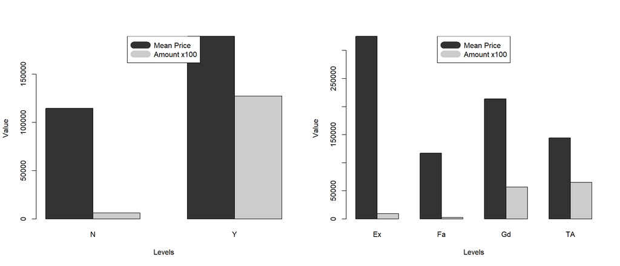

```r
par(mfrow = c(1, 2))
dummy_barplot(data_dummy$CentralAir, data_dummy$SalePrice)
dummy_barplot(data_dummy$KitchenQual, data_dummy$SalePrice)
```

Based on above analysis, we decide to use 2 dummy variables.

- CentralAir
- KitchenQual

## Multiple linear regression

In this section, we will find out the best model to satisfy all the metrics.

### Define metrics calculation

Our metrics will include: **RMSE**, **RMSE Logged**, **loocv_RMSE**, **R2**, **Adj. R2**, **bp_decision**, **bp_p_value**, **sw_decision**, **sw_p_value**, **num_params**

```r
# Calculate RMSE
rmse = function(y, y_hat){
  n = length(y)
  sqrt(sum((y - y_hat) ^ 2) / n)
}

alpha = 0.05

library(lmtest)
plot_fitted_resid = function(model, pointcol = "dodgerblue", linecol = "darkorange", main = "") {
  plot(fitted(model), resid(model),
       col = pointcol, pch = 20, cex = 1.5,
       main = main,
       xlab = "Fitted", ylab = "Residuals")
  abline(h = 0, col = linecol, lwd = 2)
}

plot_qq = function(model, pointcol = "dodgerblue", linecol = "darkorange", main = "") {
  qqnorm(resid(model), col = pointcol, pch = 20, cex = 1.5, main = main)
  qqline(resid(model), col = linecol, lwd = 2)
}

get_bp_decision = function(model, alpha) {
  decide = unname(bptest(model)$p.value <= alpha)
  ifelse(decide, "Reject", "Fail to Reject")
}

get_sw_decision = function(model, alpha) {
  decide = unname(shapiro.test(resid(model))$p.value < alpha)
  ifelse(decide, "Reject", "Fail to Reject")
}

get_num_params = function(model) {
  length(coef(model))
}

get_loocv_rmse = function(model) {
  sqrt(mean((resid(model) / (1 - hatvalues(model))) ^ 2))
}

get_adj_r2 = function(model) {
  summary(model)$adj.r.squared
}

evaluate_model = function(fit, data, response_log = FALSE, round_num = 4){
  predicts = predict(fit, newdata = data)
  predicts[predicts<1] = 1

  r2 = summary(fit)$r.squared
  if(response_log){
    rmse_log = rmse(log(data$SalePrice), predicts)
    rmse = rmse(data$SalePrice, exp(predicts))
  }
  else{
    rmse_log = rmse(log(data$SalePrice), log(predicts))
    rmse = rmse(data$SalePrice, predicts)
  }
  c(round(rmse, round_num), round(rmse_log, round_num), round(get_loocv_rmse(fit), round_num), round(r2, round_num), round(get_adj_r2(fit), round_num),
    get_bp_decision(fit, alpha), round(bptest(fit)$p.value, round_num),
    get_sw_decision(fit, alpha), round(shapiro.test(resid(fit))$p.value, round_num),
    get_num_params(fit))
}

evaluate_model_name = c("RMSE", "RMSE Logged", "loocv_RMSE", "R2", "Adj. R2", "bp_decision", "bp_p_value", "sw_decision", "sw_p_value", "num_params")
```

### Training and Testing Data

We can split the data randomly into training and testing set.

```r
set.seed(20190801)

selected_columns = c(as.character(subset(featureStat, featureStat$abs_correlations>0.05)$features), "SalePrice", "CentralAir", "KitchenQual")


data_selected = data[, which(names(data) %in% selected_columns)]


sample = sample.int(n = nrow(data_selected), size = floor(.7*nrow(data_selected)), replace = F)

training = data_selected[sample,]
testing  = data_selected[-sample,]
```

### Full model with all numeric predictors

Follwing is an additive model using all numeric predictors.

```r
fit_add_full = lm(SalePrice ~ ., data = training)

# RMSE on train and test data, log and raw
df_add_full = data.frame(Measure = evaluate_model_name,
                Train = evaluate_model(fit_add_full, training),
                Test = evaluate_model(fit_add_full, testing))

kable(df_add_full)
```

| Measure | Train | Test |
| --- | --- | --- |
| RMSE | 26066.1617 | 26575.7892 |
| RMSE Logged | 0.1471 | 0.1591 |
| loocv_RMSE | 27563.7405 | 27563.7405 |
| R2 | 0.8809 | 0.8809 |
| Adj. R2 | 0.8767 | 0.8767 |
| bp_decision | Reject | Reject |
| bp_p_value | 0 | 0 |
| sw_decision | Reject | Reject |
| sw_p_value | 0 | 0 |
| num_params | 34 | 34 |

```r
# AIC and BIC Model Selection
fit_add_aic = step(fit_add_full, trace = 0)
fit_add_bic = step(fit_add_full, trace = 0, k = log(nrow(training)))
df_add_selected = data.frame(Measure = evaluate_model_name,
                AIC_Train = evaluate_model(fit_add_aic, training),
                AIC_Test = evaluate_model(fit_add_aic, testing),
                BIC_Train = evaluate_model(fit_add_bic, training),
                BIC_Test = evaluate_model(fit_add_bic, testing)
                )

kable(df_add_selected)
```

| Measure | AIC_Train | AIC_Test | BIC_Train | BIC_Test |
| --- | --- | --- | --- | --- |
| RMSE | 26172.3169 | 26501.4203 | 26465.028 | 26483.1459 |
| RMSE Logged | 0.1471 | 0.1593 | 0.15 | 0.1582 |
| loocv_RMSE | 27169.5918 | 27169.5918 | 27343.284 | 27343.284 |
| R2 | 0.8799 | 0.8799 | 0.8772 | 0.8772 |
| Adj. R2 | 0.8771 | 0.8771 | 0.8749 | 0.8749 |
| bp_decision | Reject | Reject | Reject | Reject |
| bp_p_value | 0 | 0 | 0 | 0 |
| sw_decision | Reject | Reject | Reject | Reject |
| sw_p_value | 0 | 0 | 0 | 0 |
| num_params | 23 | 23 | 19 | 19 |

## Tranformations

From the above output, we found the additive model is not good enough. We want a smaller `RMSE Logged`. So we will apply some transformations to significant predictors.

### Response Tranformations

Based on the analysis, we want to apply log transformation to response field.

```r
fit_logprice_add_full = lm(log(SalePrice) ~ ., data = training)

# RMSE on train and test data, log and raw
df_logprice_add_full = data.frame(Measure = evaluate_model_name,
                Train = evaluate_model(fit_logprice_add_full, training),
                Test = evaluate_model(fit_logprice_add_full, testing))

kable(df_logprice_add_full)
```

| Measure | Train | Test |
| --- | --- | --- |
| RMSE | 199641.4549 | 199960.1996 |
| RMSE Logged | 9.5727 | 9.5661 |
| loocv_RMSE | 0.1201 | 0.1201 |
| R2 | 0.9051 | 0.9051 |
| Adj. R2 | 0.9018 | 0.9018 |
| bp_decision | Reject | Reject |
| bp_p_value | 0.0122 | 0.0122 |
| sw_decision | Reject | Reject |
| sw_p_value | 0 | 0 |
| num_params | 34 | 34 |

```r
# AIC and BIC Model Selection
fit_logprice_add_aic = step(fit_logprice_add_full, trace = 0)
fit_logprice_add_bic = step(fit_logprice_add_full, trace = 0, k = log(nrow(training)))
df_logprice_add_selected = data.frame(Measure = evaluate_model_name,
                AIC_Train = evaluate_model(fit_logprice_add_aic, training),
                AIC_Test = evaluate_model(fit_logprice_add_aic, testing),
                BIC_Train = evaluate_model(fit_logprice_add_bic, training),
                BIC_Test = evaluate_model(fit_logprice_add_bic, testing)
                )

kable(df_logprice_add_selected)
```

| Measure | AIC_Train | AIC_Test | BIC_Train | BIC_Test |
| --- | --- | --- | --- | --- |
| RMSE | 199641.4549 | 199960.1992 | 199641.4555 | 199960.1994 |
| RMSE Logged | 9.5727 | 9.5661 | 9.5727 | 9.5661 |
| loocv_RMSE | 0.1185 | 0.1185 | 0.1196 | 0.1196 |
| R2 | 0.9049 | 0.9049 | 0.9017 | 0.9017 |
| Adj. R2 | 0.9024 | 0.9024 | 0.8999 | 0.8999 |
| bp_decision | Reject | Reject | Reject | Reject |
| bp_p_value | 0.0045 | 0.0045 | 0.0017 | 0.0017 |
| sw_decision | Reject | Reject | Reject | Reject |
| sw_p_value | 0 | 0 | 0 | 0 |
| num_params | 25 | 25 | 19 | 19 |

### Predictor Tranformations

We will make transformations to some “significant” predictors:

- Feature range is larger (Area), we picked the LotArea, GrLivArea, X1stFlrSF, GarageArea

```r
fit_logprice_transform_full = lm(log(SalePrice) ~ . + log(LotArea) + log(GrLivArea)+log(X1stFlrSF)+log(GarageArea), data = training)

df_logprice_transform_full = data.frame(Measure = evaluate_model_name,
                Train = evaluate_model(fit_logprice_transform_full, training, TRUE),
                Test = evaluate_model(fit_logprice_transform_full, testing, TRUE))

kable(df_logprice_transform_full)
```

| Measure | Train | Test |
| --- | --- | --- |
| RMSE | 21178.4379 | 24258.0115 |
| RMSE Logged | 0.1103 | 0.1218 |
| loocv_RMSE | 0.1162 | 0.1162 |
| R2 | 0.9119 | 0.9119 |
| Adj. R2 | 0.9084 | 0.9084 |
| bp_decision | Reject | Reject |
| bp_p_value | 0.0484 | 0.0484 |
| sw_decision | Reject | Reject |
| sw_p_value | 0 | 0 |
| num_params | 38 | 38 |

## Interaction

For top important features

```r
fit_logprice_transform_interaction_full = lm(log(SalePrice) ~ . + (OverallQual + GrLivArea + GarageCars + TotalBsmtSF + X1stFlrSF  + MasVnrArea + Fireplaces+ YearBuilt ) ^2 +YearBuilt:TotalBsmtSF:X1stFlrSF + YearBuilt:MasVnrArea:GarageCars + log(LotArea)  + log(GrLivArea)+log(X1stFlrSF)+log(GarageArea) , data = training)

df_logprice_transform_interaction_full = data.frame(Measure = evaluate_model_name,
                Train = evaluate_model(fit_logprice_transform_interaction_full, training, TRUE),
                Test = evaluate_model(fit_logprice_transform_interaction_full, testing, TRUE))

kable(df_logprice_transform_interaction_full)
```

| Measure | Train | Test |
| --- | --- | --- |
| RMSE | 20037.1653 | 23343.5831 |
| RMSE Logged | 0.1048 | 0.1207 |
| loocv_RMSE | 0.1154 | 0.1154 |
| R2 | 0.9204 | 0.9204 |
| Adj. R2 | 0.9145 | 0.9145 |
| bp_decision | Fail to Reject | Fail to Reject |
| bp_p_value | 0.36 | 0.36 |
| sw_decision | Reject | Reject |
| sw_p_value | 0 | 0 |
| num_params | 68 | 68 |

The `bptest` is met in this model.

## Model selection

```r
# AIC
fit_logprice_transform_interaction_aic = step(fit_logprice_transform_interaction_full,trace = 0)

df_logprice_transform_interaction_aic = data.frame(Measure = evaluate_model_name,
                Train = evaluate_model(fit_logprice_transform_interaction_aic, training, TRUE),
                Test = evaluate_model(fit_logprice_transform_interaction_aic, testing, TRUE))
kable(df_logprice_transform_interaction_aic)
```

| Measure | Train | Test |
| --- | --- | --- |
| RMSE | 20154.9709 | 23113.9869 |
| RMSE Logged | 0.1054 | 0.1202 |
| loocv_RMSE | 0.1125 | 0.1125 |
| R2 | 0.9196 | 0.9196 |
| Adj. R2 | 0.9152 | 0.9152 |
| bp_decision | Fail to Reject | Fail to Reject |
| bp_p_value | 0.0785 | 0.0785 |
| sw_decision | Reject | Reject |
| sw_p_value | 0 | 0 |
| num_params | 51 | 51 |

Currently, it’s best the model with best RMSE. However, it can not meet the `shaprio-test`.

## Outlier diagnostics

We will try to remove some outliers to meet the assumptions in this section.

```r
df_logprice_transform_interaction = lm(formula = log(SalePrice) ~ LotFrontage + OverallQual + OverallCond +
    YearBuilt  + BsmtFinSF1 + TotalBsmtSF +
    log(X2ndFlrSF +1) + BsmtFullBath + FullBath + HalfBath +
    KitchenAbvGr + Fireplaces + GarageCars  + WoodDeckSF +
    OpenPorchSF + ScreenPorch + CentralAir + KitchenQual + log(LotArea) +
    log(GrLivArea):YearBuilt + log(GarageArea) + I(X1stFlrSF^2)+
    OverallQual:MasVnrArea + X2ndFlrSF:Fireplaces:YearBuilt,
    data = training)

cd_fit = cooks.distance(df_logprice_transform_interaction)
large_cd_fit = cd_fit > 4 / length(cd_fit)

df_logprice_transform_interaction_outlier = lm(formula = log(SalePrice) ~ LotFrontage + OverallQual + OverallCond +
    YearBuilt  + BsmtFinSF1 + TotalBsmtSF +
    log(X2ndFlrSF +1) + BsmtFullBath + FullBath + HalfBath +
    KitchenAbvGr + Fireplaces + GarageCars  + WoodDeckSF +
    OpenPorchSF + ScreenPorch + CentralAir + KitchenQual + log(LotArea) +
    log(GrLivArea):YearBuilt + log(GarageArea) + I(X1stFlrSF^2)+
    OverallQual:MasVnrArea + X2ndFlrSF:Fireplaces:YearBuilt,
    data = training,
    subset = cd_fit <= 4 / length(cd_fit)
    )
```

```r
#single table comparsion of the model
df = data.frame(Measure = evaluate_model_name,

                Train = evaluate_model(df_logprice_transform_interaction, training, TRUE),
                Test = evaluate_model(df_logprice_transform_interaction, testing, TRUE),
                NoOutlier_Train = evaluate_model(df_logprice_transform_interaction_outlier, training, TRUE),
                NoOutlier_Test = evaluate_model(df_logprice_transform_interaction_outlier, testing, TRUE)
                )

kable(df)
```

| Measure | Train | Test | NoOutlier_Train | NoOutlier_Test |
| --- | --- | --- | --- | --- |
| RMSE | 22334.2285 | 24415.613 | 22568.0368 | 24282.6557 |
| RMSE Logged | 0.1139 | 0.1213 | 0.1145 | 0.121 |
| loocv_RMSE | 0.1178 | 0.1178 | 0.0881 | 0.0881 |
| R2 | 0.9061 | 0.9061 | 0.9407 | 0.9407 |
| Adj. R2 | 0.9035 | 0.9035 | 0.9389 | 0.9389 |
| bp_decision | Fail to Reject | Fail to Reject | Fail to Reject | Fail to Reject |
| bp_p_value | 0.1092 | 0.1092 | 0.1809 | 0.1809 |
| sw_decision | Reject | Reject | Fail to Reject | Fail to Reject |
| sw_p_value | 0 | 0 | 0.1373 | 0.1373 |
| num_params | 27 | 27 | 27 | 27 |

Got it! Both equal-variance assumption and normality assumption are met in this model.

# Results

```r
fit_final = df_logprice_transform_interaction_outlier
```

Based the above the above table, the best model is selected and stored as `fit_final`

## Parameters of Final Model

The expression of our final model is

$$log(SalePrice) = \beta_0 + \beta_1x_{LotFrontage} + \beta_2x_{OverallQual} + \beta_3x_{OverallCond} + \beta_4x_{YearBuilt} + \beta_5x_{BsmtFinSF1} + \beta_6x_{TotalBsmtSF} \\
+ \beta_7log(x_{X2ndFlrSF}+1) + \beta_8x_{BsmtFullBath} + \beta_9x_{FullBath} + \beta_{10}x_{HalfBath} + \beta_{11}x_{KitchenAbvGr} + \beta_{12}x_{Fireplaces} \\
+ \beta_{13}x_{GarageCars} + \beta_{14}x_{WoodDeckSF} + \beta_{15}x_{OpenPorchSF} + \beta_{16}x_{ScreenPorch} + \beta_{17}x_{CentralAirY} + \beta_{18}x_{KitchenQualFa} \\
+ \beta_{19}x_{KitchenQualGd} + \beta_{20}x_{KitchenQualTA} + \beta_{21}log(x_{LotArea}) + \beta_{22}log(x_{GarageArea}) + \beta_{23}x_{X1stFlrSF}^2 + \beta_{24}x_{YearBuilt}log(x_{GrLivArea}) \\
+ \beta_{25}x_{OverallQual}x_{MasVnrArea} + \beta_{26}x_{YearBuilt}x_{Fireplaces}x_{X2ndFlrSF}$$

There are totally 27 parameters.

## Variance Inflation Factor (VIF)

```r
library(faraway)
sort(vif(fit_final), decreasing = TRUE)
```

```
##       YearBuilt:log(GrLivArea)             log(X2ndFlrSF + 1)
##                         15.856                          9.201
##                  KitchenQualTA                 I(X1stFlrSF^2)
##                          7.682                          7.505
##                  KitchenQualGd                      YearBuilt
##                          5.970                          4.635
##                     GarageCars                log(GarageArea)
##                          4.134                          3.942
##                    TotalBsmtSF                    OverallQual
##                          3.654                          3.387
##                       FullBath YearBuilt:Fireplaces:X2ndFlrSF
##                          3.214                          3.131
##                       HalfBath                     BsmtFinSF1
##                          2.419                          2.107
##                     Fireplaces                   BsmtFullBath
##                          1.953                          1.865
##                   log(LotArea)                    OverallCond
##                          1.550                          1.495
##                  KitchenQualFa         OverallQual:MasVnrArea
##                          1.437                          1.400
##                    CentralAirY                   KitchenAbvGr
##                          1.346                          1.299
##                    OpenPorchSF                     WoodDeckSF
##                          1.251                          1.181
##                    LotFrontage                    ScreenPorch
##                          1.150                          1.099
```

- YearBuilt:log(GrLivArea) has the largest VIF, 15.856.
- We have picked the predictors without collinearity issue as possible. It can help us to undertand the relationship.

## Residual diagnostics

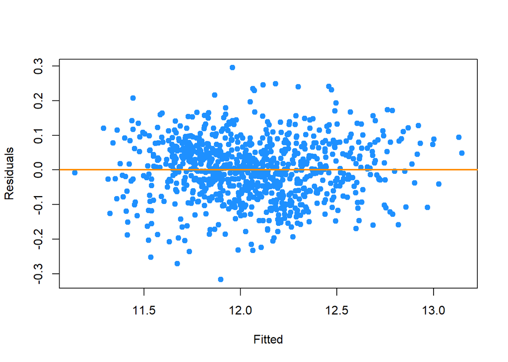

```r
plot_fitted_resid(fit_final)
```

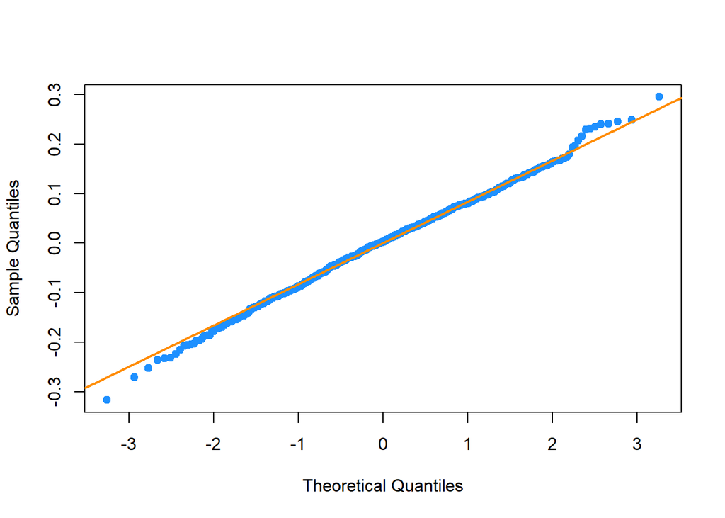

```r
plot_qq(fit_final)
```

```r
df = data.frame(Measure = evaluate_model_name,
                fit_final_Train = evaluate_model(fit_final, training, TRUE),
                fit_final_Test = evaluate_model(fit_final, testing, TRUE))

kable(df)
```

| Measure | fit_final_Train | fit_final_Test |
| --- | --- | --- |
| RMSE | 22568.0368 | 24282.6557 |
| RMSE Logged | 0.1145 | 0.121 |
| loocv_RMSE | 0.0881 | 0.0881 |
| R2 | 0.9407 | 0.9407 |
| Adj. R2 | 0.9389 | 0.9389 |
| bp_decision | Fail to Reject | Fail to Reject |
| bp_p_value | 0.1809 | 0.1809 |
| sw_decision | Fail to Reject | Fail to Reject |
| sw_p_value | 0.1373 | 0.1373 |
| num_params | 27 | 27 |

# Discussion

In this project, we want to find a suitable model to predict the price of a house given the properties of it. But the original data has 79 predictors, which seems too much for a linear model. So we should do data cleaning at first. We firstly removed predictors that have too many `Nan`, meaning the data may not be available for most houses. Then we split the predictors into factor predictors and numerical predictors.

## Best way to use dummy variables

At the same time, we also investigated the dummy variables. We hope to find a set of dummy variables to convey some information that numerical variables don’t have. A dummy variable should have a balanced amount of observations among different levels, and the house price of each level should have an obvious difference. So we selected `CentralAir` and `KitchenQual` as the dummy variable in our model.

Moreover, we did a lot of tuning to make the model to satisfy the equal-variance assumption and normality assumption.

## Outlier Diagnostics is siginificant

In this project, we were struggling on improving the model to pass the BP test and Shapiro-Test. After some modeling analysis. We found that by using outlier diagnostics, we can remove very few outliers by appling function cooks.distance().

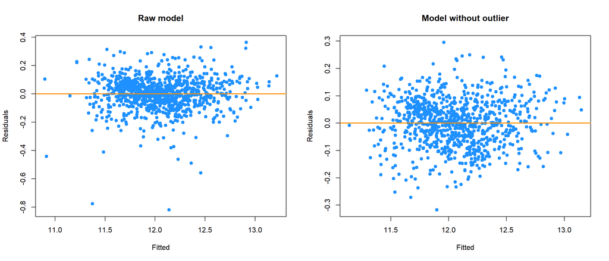

```r
par(mfrow = c(1, 2))
plot_fitted_resid(df_logprice_transform_interaction, main = "Raw model")
plot_fitted_resid(df_logprice_transform_interaction_outlier, main = "Model without outlier")
```

Above Fitted verus Residual chart proves that removing outlier can improve the model significantly. Let’s further prove that by compare the Q-Q plot.

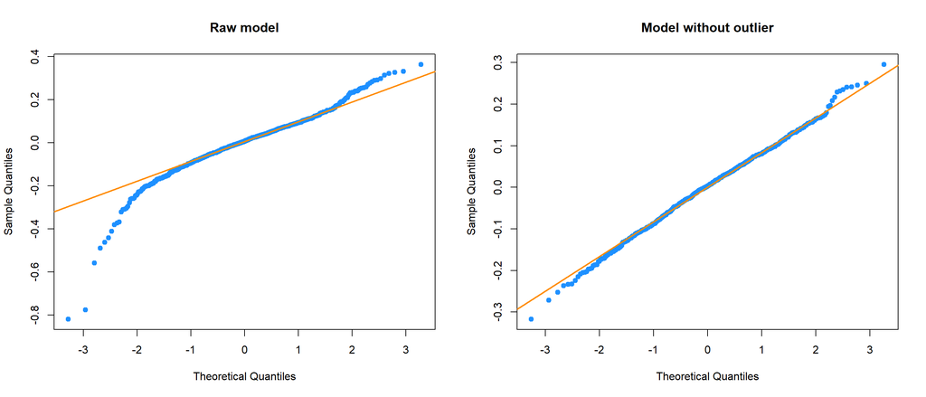

```r
par(mfrow = c(1, 2))
plot_qq(df_logprice_transform_interaction, main = "Raw model")
plot_qq(df_logprice_transform_interaction_outlier, main = "Model without outlier")
```

## Can we try a more complex model

In order to try a more complex model, let’s take the selected features and apply a two way interaction to all these predictors.

```r
fit_complex = lm(formula = log(SalePrice) ~ (LotFrontage + OverallQual + OverallCond + BsmtFinSF1 + TotalBsmtSF +  X2ndFlrSF + BsmtFullBath + FullBath + HalfBath + KitchenAbvGr + Fireplaces + GarageCars  + WoodDeckSF + OpenPorchSF + ScreenPorch + LotArea + GrLivArea + YearBuilt + GarageArea) ^ 2,data = training)

df = data.frame(Measure = evaluate_model_name,
                fit_final_Train = evaluate_model(fit_complex, training, TRUE),
                fit_final_Test = evaluate_model(fit_complex, testing, TRUE))

kable(df)
```

| Measure | fit_final_Train | fit_final_Test |
| --- | --- | --- |
| RMSE | 18308.6204 | 43292.6228 |
| RMSE Logged | 0.0973 | 0.143 |
| loocv_RMSE | Inf | Inf |
| R2 | 0.9315 | 0.9315 |
| Adj. R2 | 0.9146 | 0.9146 |
| bp_decision | Fail to Reject | Fail to Reject |
| bp_p_value | 0.9935 | 0.9935 |
| sw_decision | Reject | Reject |
| sw_p_value | 0 | 0 |
| num_params | 191 | 191 |

It’s clear that the more complex model start to overfitting which is a bad model. That’s a also very good learning from this lesson. Too complex model is usually a bad model which may perform good on training data but does bad in the testing data.

## A prediction example

We can pick an observation from test set.

```r
data_test = read.csv("test.csv")
(data_test_1_confidence = exp(predict(fit_final, newdata = data_test[1,], interval = c("confidence"), level = 0.95)))
```

```
##      fit    lwr    upr
## 1 122902 118848 127095
```

- Since the `test.csv` data set do not contain the Sale price, we can not double check the result.
- However, with using the final model `fit_final`, we are 95% confidence that the mean Sale price is 1.22910^{5} within 1.188510^{5} and 1.270910^{5}

# Appendix

When we proposal this project, we are interested to this HOT problem. And this dataset gives us a chance to look into the data on what really influences the value of a house, so our team members are excited to take a look!

Solving this problem to come out a good model fitting the house sale price using so many predictors is not a easy work to us. We tried nearly all the solutions learned from this lession. Finally, we got a great model which can fit the data well. By applying all the model test and anlysis techniques, we verified the model using multi algorithms (RMSE, bp-test, etc) on both training and testing data. And we are lucky that the model is a pretty good one.

In the next step, We may apply the model over the houses we have known around us, and analyse whether there can be some potential influence to the house price that cannot be reflected by data.